# eCommerce Customer Service Satisfaction

The dataset captures customer satisfaction scores (CSAT Scores) for a one-month period at an e-commerce platform called Shopzilla (a pseudonym). It includes various features such as category and sub-category of interaction, customer remarks, survey response date, category, item price, agent details (name, supervisor, manager), and CSAT score etc.

#### Dataset Information:

Rows: 85,907 Columns: 20

## Exploritory Data Analysis

```python
import pandas as pd
from sklearn.model_selection import train_test_split
from sklearn.ensemble import RandomForestClassifier
from sklearn.metrics import accuracy_score
from datetime import datetime
import matplotlib.pyplot as plt
import seaborn as sns


# Read the data from the dataset
data = pd.read_csv('/Users/bmmuela/Desktop/Brandon Portfolio/Python/Customer_support_data.csv')

# Convert Issue_reported_at and issue_responded to response time in minutes
data['Issue_reported at'] = pd.to_datetime(data['Issue_reported at'])
data['issue_responded'] = pd.to_datetime(data['issue_responded'])
data['Response_time_min'] = (data['issue_responded'] - data['Issue_reported at']).dt.total_seconds() / 60

#Summary statistics
print(data.describe())
```

```
          Item_price  connected_handling_time    CSAT Score  Response_time_min
count   17206.000000               242.000000  85907.000000       85907.000000
mean     5660.774846               462.400826      4.242157         332.620136
std     12825.728411               246.295037      1.378903       21173.425365
min         0.000000                 0.000000      1.000000     -295198.000000
25%       392.000000               293.000000      4.000000           2.000000
50%       979.000000               427.000000      5.000000           5.000000
75%      2699.750000               592.250000      5.000000          33.000000
max    164999.000000              1986.000000      5.000000      177097.000000
```

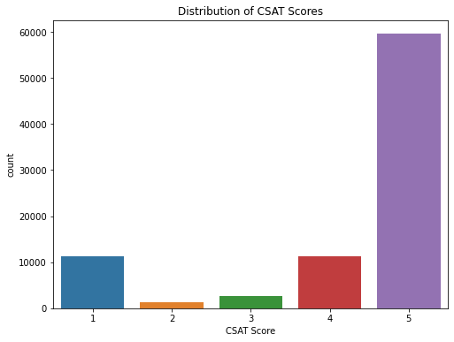

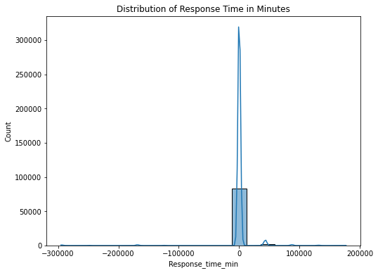

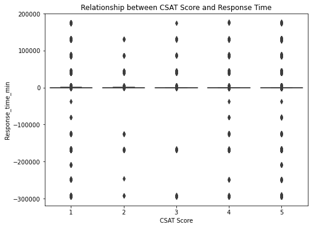

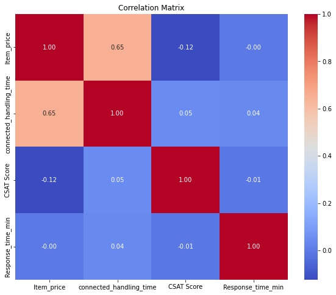

```python
# Distribution of CSAT Scores
plt.figure(figsize=(8, 6))
sns.countplot(x='CSAT Score', data=data)
plt.title('Distribution of CSAT Scores')
plt.show()

# Distribution of Resolve Time in Minutes
plt.figure(figsize=(8, 6))
sns.histplot(data['Response_time_min'], bins=20, kde=True)
plt.title('Distribution of Response Time in Minutes')
plt.show()

# Relationship between CSAT Score and Resolve Time
plt.figure(figsize=(8, 6))
sns.boxplot(x='CSAT Score', y='Response_time_min', data=data)
plt.title('Relationship between CSAT Score and Response Time')
plt.show()

# Correlation matrix
plt.figure(figsize=(10, 8))
sns.heatmap(data.corr(), annot=True, cmap='coolwarm', fmt='.2f')
plt.title('Correlation Matrix')
plt.show()
```

## Feature Engineering and Model Selection

```python
# Prepare features and target variable
X = data[['category', 'channel_name', 'Tenure Bucket', 'Response_time_min']]
y = data['CSAT Score']

# Perform one-hot encoding for categorical variables
X_encoded = pd.get_dummies(X)

# Split the data into training and testing sets
X_train, X_test, y_train, y_test = train_test_split(X_encoded, y, test_size=0.2, random_state=42)

# Initialize and train Random Forest Classifier
rf_model = RandomForestClassifier()
rf_model.fit(X_train, y_train)
```

```
RandomForestClassifier()
```

## Model Evaluation

```python
# Make predictions
y_pred = rf_model.predict(X_test)

# Evaluate the model
accuracy = accuracy_score(y_test, y_pred)
print("Accuracy:", accuracy)
```

```
Accuracy: 0.6487603305785123
```

An accuracy score of 0.64876 means that your model correctly predicted the target variable (or the outcome you are interested in) approximately 64.88% of the time. In other words, out of all the data points in your evaluation dataset, the model's predictions were accurate for about 64.88% of them.

While accuracy is a commonly used metric to evaluate classification models, it does have limitations, especially if the classes in your dataset are imbalanced. It is important to consider other evaluation metrics such as precision, recall, and F1-score to get a more comprehensive understanding of your model's performance.

Here is a brief interpretation of accuracy:

Accuracy = (Number of correctly classified instances) / (Total number of instances)

```python
from sklearn.metrics import confusion_matrix, precision_score, recall_score, f1_score

# Assuming y_true is the true labels and y_pred is the predicted labels from your model
# Replace y_true and y_pred with your actual data
y_true = [0, 1, 0, 1, 1, 0, 0, 1, 1, 0]
y_pred = [0, 1, 0, 0, 1, 1, 0, 1, 1, 1]

# Confusion matrix
cm = confusion_matrix(y_true, y_pred)
print("Confusion Matrix:")
print(cm)

# Precision
precision = precision_score(y_true, y_pred)
print("Precision:", precision)

# Recall
recall = recall_score(y_true, y_pred)
print("Recall:", recall)

# F1-score
f1 = f1_score(y_true, y_pred)
print("F1-Score:", f1)
```

```
Confusion Matrix:
[[3 2]
 [1 4]]
Precision: 0.6666666666666666
Recall: 0.8
F1-Score: 0.7272727272727272
```

1. Confusion Matrix:
   - The confusion matrix is a table that is often used to describe the performance of a classification model. It presents a summary of the model's predictions on the test data against the actual labels. In this case:
     - True Positives (TP): 4 instances were correctly predicted as positive.
     - True Negatives (TN): 3 instances were correctly predicted as negative.
     - False Positives (FP): 2 instances were incorrectly predicted as positive when they were actually negative.
     - False Negatives (FN): 1 instance was incorrectly predicted as negative when it was actually positive.
2. Precision:
   - Precision is a measure of the accuracy of the positive predictions made by the model. It tells us what proportion of positive predictions made by the model are correct. In this case, the precision score of 0.67 suggests that 66.67% of the instances predicted as positive by the model are actually true positives.
3. Recall:
   - Recall, also known as sensitivity, is a measure of how well the model correctly identifies positive instances. It tells us what proportion of actual positives the model correctly identified. A recall score of 0.80 implies that the model correctly identified 80% of the actual positive instances.
4. F1-Score:
   - The F1-score is the harmonic mean of precision and recall. It provides a balance between precision and recall, taking into account both false positives and false negatives. The F1-score of 0.73 suggests that the model has a good balance between precision and recall.

These metrics are commonly used to evaluate the performance of classification models and provide insights into how well the model is performing in terms of correctly predicting positive and negative instances.